# DUIA: the Database on Urban Inequality and Amenities

Frederico Ramos and Justus Uitermark

### Sample of Cities

The sample includes 86 cities distributed around all the continents, with few cities in Europe and North America. The interactive map bellow shows the spatial distribution of the cities with simbols proportional to the city size. The Atlas of Urban Expansion (http://atlasofurbanexpansion.org/) and the IPUMS International (https://international.ipums.org/international/) are the main data sources.

[interactive chart not shown]

The data set includes the measurement of urban extent depicted by satellite imagery in different periods around the years 1990, 2000 and 2015. The availability of census data in different periods varies across the sample and was organized in ways that is most close the period when the images are available. The observations were then aggregated in 3 time period: T1, T2 and T3. The scatter plot bellow shows the distribution of the year when the census data was collected and the year of the satellite imagery.

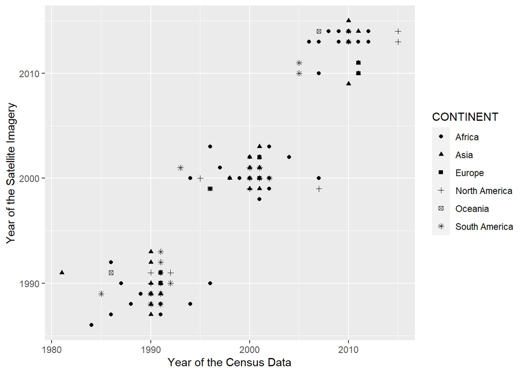

The tables below present the descriptive statistic for the population size in different periods.

TIME 1

| CONTINENT | n | Avrg_population | Min_population | Max_population |
| --- | --- | --- | --- | --- |
| Africa | 11 | 1719558.5 | 84150 | 9621785 |
| Asia | 14 | 2930154.1 | 26943 | 9031508 |
| Europe | 2 | 2193465.7 | 744994 | 3641938 |
| North America | 5 | 2925762.4 | 197217 | 9781971 |
| Oceania | 1 | 25573.6 | 25574 | 25574 |
| South America | 16 | 2562434.0 | 6441 | 13654119 |

TIME 2

| CONTINENT | n | Avrg_population | Min_population | Max_population |
| --- | --- | --- | --- | --- |
| Africa | 17 | 2288066.7 | 143908 | 11928479 |
| Asia | 46 | 3820964.7 | 132115 | 14460678 |
| Europe | 2 | 2583047.0 | 828396 | 4337697 |
| North America | 6 | 3125589.0 | 141815 | 12514239 |
| Oceania | 1 | 162384.8 | 162385 | 162385 |
| South America | 16 | 3178351.3 | 88195 | 16866432 |

TIME 3

| CONTINENT | n | Avrg_population | Min_population | Max_population |
| --- | --- | --- | --- | --- |
| Africa | 15 | 3980391.7 | 326160 | 15734934 |
| Asia | 40 | 5716503.9 | 139273 | 24657221 |
| Europe | 2 | 3057840.1 | 859431 | 5256249 |
| North America | 5 | 4897271.8 | 160355 | 17765121 |
| Oceania | 1 | 182140.2 | 182140 | 182140 |
| South America | 13 | 4118233.7 | 97888 | 19609222 |

### Populational density and fragmentation of the built up area

The density plot shows that cities diminished populational density over the three periods and increased the fragmentation of the built up area

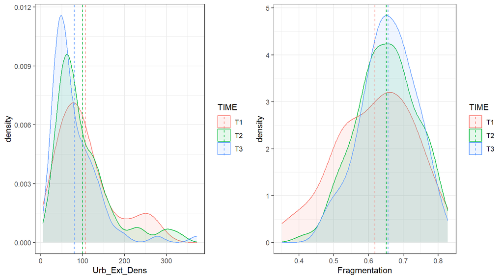

### Access to water

Analyzing the evolution of the access to piped water is possible to observe a diversity of situations across the cities. Cities in Latin America managed to consistently increase the provision of piped water over the period. In the same period, some cities couldn`t manage to guarantee the access.

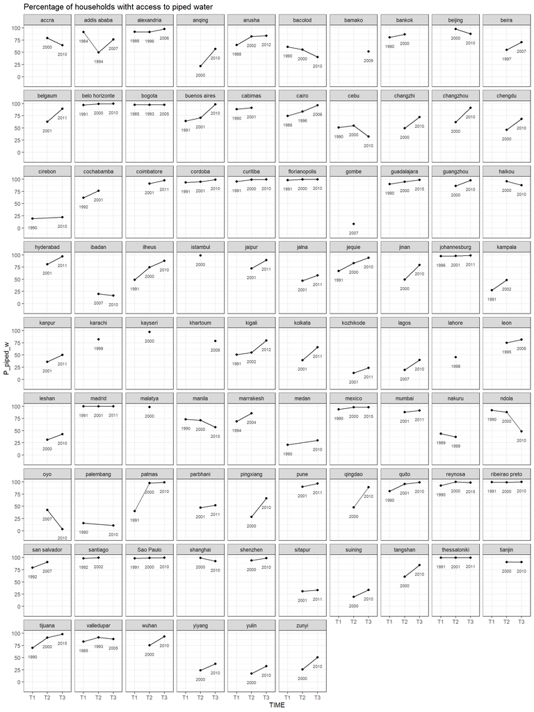

The general evolution by continent shows that some cities in Asia and Africa had worsened the access over the three periods.

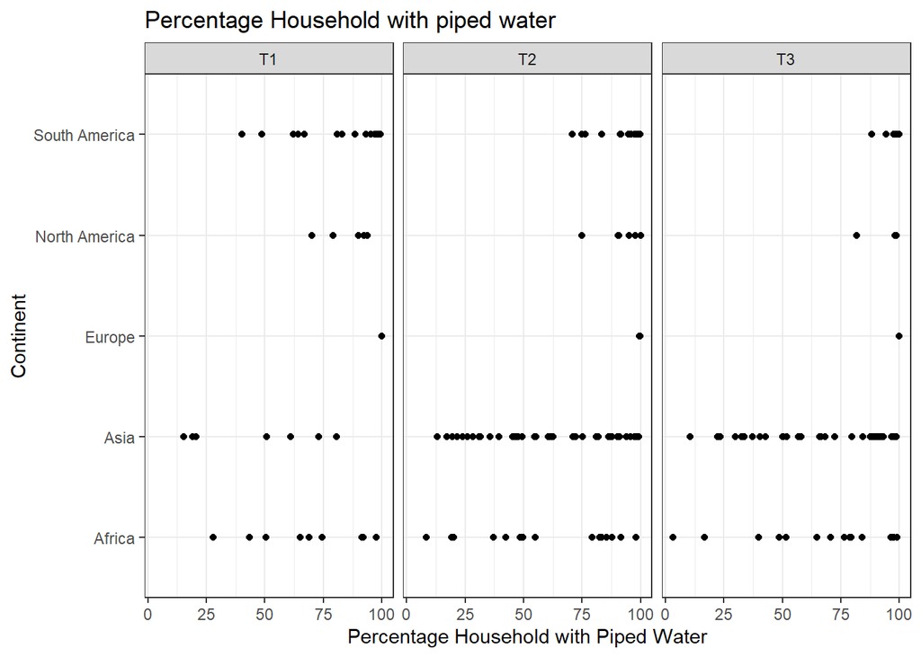

The evolution of the population of the city and the access to piped water follows specific patterns by city. In general, the most populous cities managed to increase the access for piped water being Manila the remarkable exception of this group.

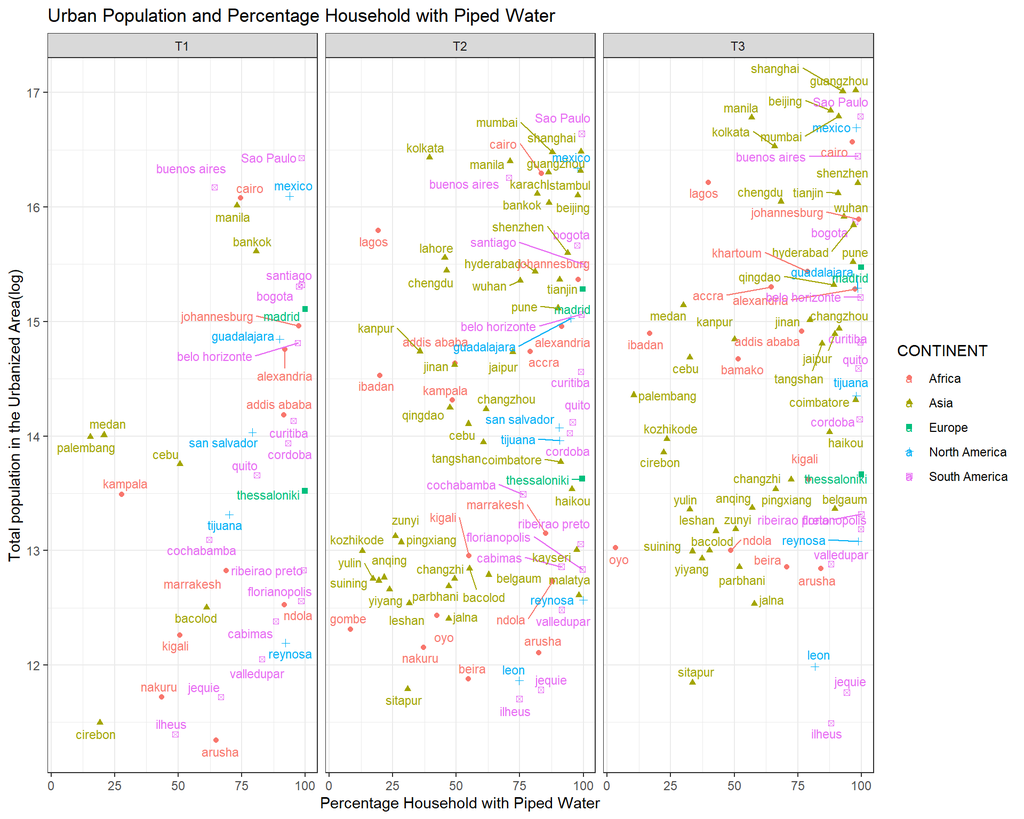

For some cities in India, we have detailed categories by Local of water provision for 2001 and 2011

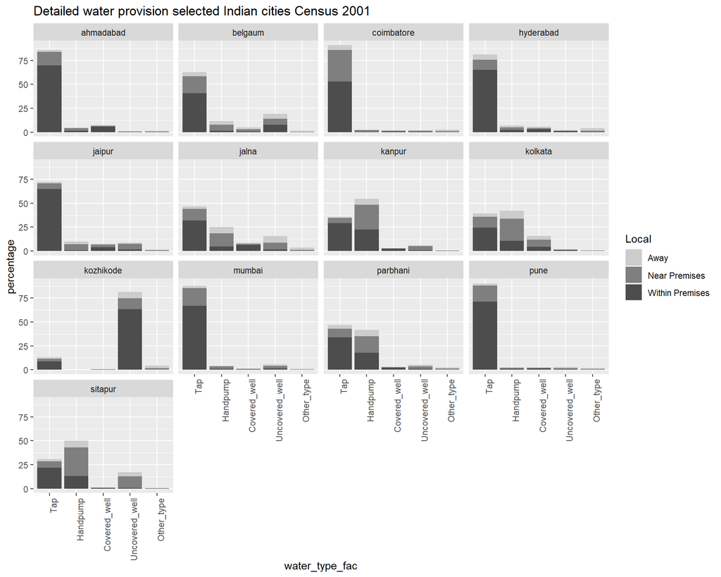

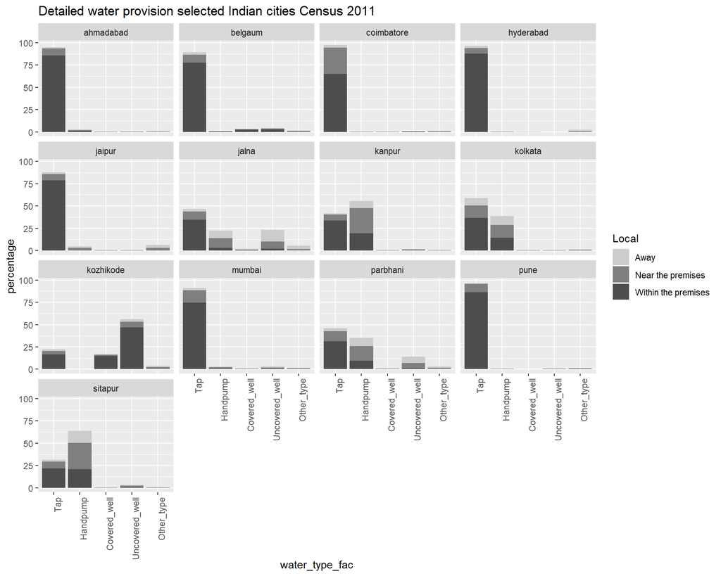

### Asset Inequality Index

Where IPUMS microdata is available, there is a possibility to conduct research at the level of the household. This represents an important quality since many of the currently available databases only present aggregate indicators and indexes. To construct the index for household asset inequality, we replicate McKenzie’s approach but take cities, not the countries, as objects of analysis (McKenzie 2005). The basic idea of the index is to use Principal Component Analysis (PCA) for reducing multidimensionality commonly present in large datasets and to measure inequality on the first component, that is, the component that accounts for most of the variance.

#### The evolution of Asset Inequality Index for selected cities (in black) and countries (in red)

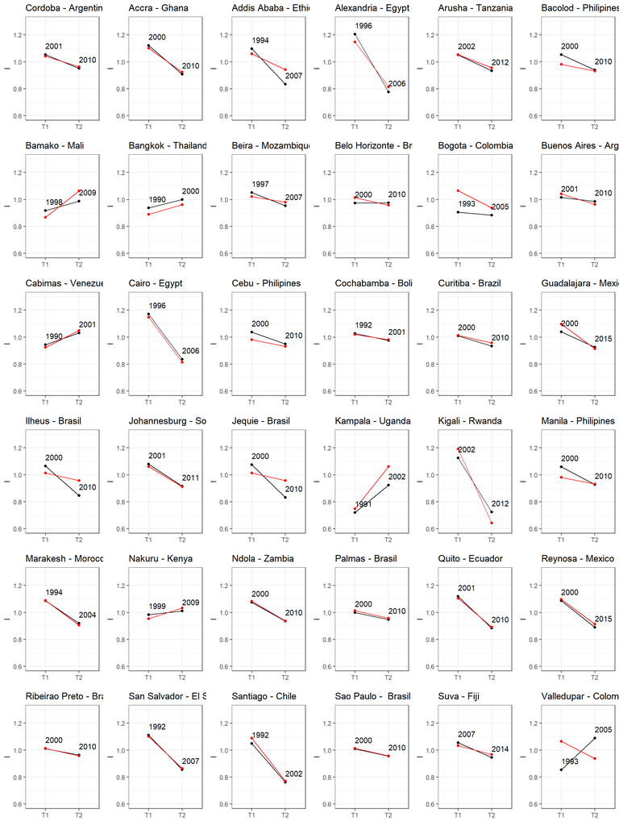